# Replication of Study Attention Alters Perceived Attractiveness (Experiment 3) by Störmer & Alvarez (2016, Psychological Science)

Minyoung Lee (minyoung.lee@stanford.edu)

March 25, 2017

## Introduction

In their study, Störmer & Alvarez (2016) tested whether attention can alter the appearance of real-world stimuli. They asked three questions: **1)** Does attention alter perceived attractiveness of faces? **2)** Is the change in attractiveness judgments driven by exogenous (involuntary) attention? **3)** Does the attentional cue influence attractive judgments by modulating the apparent local contrast of the faces? Their results showed that attention altered the perception of facial attractiveness which belongs to higher-level aspects of perception. **In the current replication project, we aim to replicate Experiment 3 of the original study in which the authors found that attention increased the apparent contrast around the eye region of faces which has been reported to modulate facial attractiveness.**

## Methods

### Power Analysis

The effect size for the key statistical test (the paired-samples *t* test) reported in the original paper was $\eta^2=0.30$. We computed *Cohen’s d<sub>z</sub>* based on statistics provided in the paper (55.8% vs. 45.8%, $t$(15) = 2.51, $p$ = .02, $\eta^2$=0.30).

```r
N <- 16
meanDiff <- 55.8 - 45.8
t <- 2.51  # t = meanDiff / se_of_meanDiff
se_d <- meanDiff/t
s_d <- se_d * sqrt(N) # standard deviation of the mean differences
d_z <- meanDiff / s_d
# also equals
d_z <- t/sqrt(N)
```

Based on the computed effect size of *d<sub>z</sub>* = 0.6275, we performed post hoc power analysis using G*Power. The analysis indicated that the power of the original study was *0.65*. We would need a sample size of *N* = 22 to achieve 80% power, *N* = 29 to achieve 90% power, and *N* = 35 to achieve 95% power to be able to detect the reported effect size. We aim to acieve 80% power. However, to shorten the duration of the experiment for each participant, we are going to split the experiment into halves and double the number of participants. That will give us *N* = 44.

### Planned Sample

We plan to recruit 44 US participants on the Amazon Mechanical Turk.

### Materials

```
"A small black fixation cross (0.5° × 0.5°) was presented in the center of the screen throughout the experiment. Two small horizontal lines (~0.5° long) were presented to the left and right of fixation and served as landmarks for the horizontal midline of the screen. The target display consisted of …
```

The experimental materials used in the original study (i.e., contrast manipulated face images) were provided by the original authors. Although we used the same stimuli, the size, brightness and spacing of stimuli could not be precisely controlled due to several constraints in the experimental settings as our experiment was conducted online on the Amazon Mechanical Turk (e.g., different displays, web browing environments, etc). However, we tried to keep the relative sizes and positions of stimuli as close to those in the original study as possible.

### Procedure

```
"The experiment was conducted in a dimly lit room, and the stimuli were presented on a 15-in. CRT display (1,280 × 1,024 pixels; 85 Hz) whose background color was set to gray (111 cd/m2). Participants viewed the stimuli at a distance of 57 cm, and a chin rest was used to stabilize their heads. Parti…
Participants were instructed to maintain their gaze on the fixation cross in the center of the gray screen throughout each experimental block. When they moved their gaze more than 1.5° away from fixation, the trial was aborted. At the beginning of each trial, a black circle appeared briefly (~70 ms)…

"Experiment 3 followed the same procedure as Experiment 1 except for the task instructions. Participants were asked to report the vertical positioning (upward or downward) of the face that appeared to have higher contrast around the eye region by pressing the up- or down-arrow key on a keyboard. Pri…
```

The experimental procedures were followed precisely, excxept for the following changes:

- The presentation of stimuli was controlled by javascript.
- As mentioned before, we did not have control over the size, resolution and refresh rate of displays. Also, the testing environments were considerably different from the original study – Turkers’ presumably worked from their home viewing the screen at a random distance without a chin rest and without an eye tracker recording their gaze positions.
- There were also a few differences in the duration of stimulus presentation. Considering that the most common refresh rates for computer screens include 30Hz and 60Hz, we fixed the lengths of cue and face presentation at 66 ms instead of 70 ms and 58 ms, respectively. Thus, the stimulus onset asynchrony (SOA) between the attentional cue and the faces in our version of the experiment was 132 ms which was 4 ms longer than in the original study. However, we did not expect that difference to be effective enough to abolish the attentional cueing effect.
- To reduce the length of the experiment 10 instead of 20 faces were used for each participant. We splitted the faces into two sets and randomly assigned which set would be used for each participant. The remaining 10 faces appeared in practice trials.
- Participants practiced the task at lower speed in some portion of practice trials.

### Analysis Plan

> There was a main effect of actual contrast level on contrast judgments, $F$(4, 15) = 27.93, $p$= .0001, $\eta^2$ = .31. Participants chose the face with higher contrast around the eye region more often than the face with lower contrast around the eye region. As in the previous experiments, our main analysis focused on the matched-face trials, in which identical faces were presented at Contrast Level 3. As shown in Figure 4b, **when the two faces were physically identical, participants tended to judge the face at the cued location to have higher contrast than the face at the uncued location (55.8% vs.45.8%), $t$(15) = 2.51, $p$ = .02, $\eta^2$ = .30.** (from Störmer & Alvarez p.568.)

#### Key Analysis of Interest

The **dependent variable** (DV) of interest in Experiment 3 of the original study was **the *percentage* of trials where participants judged the *“test” face* as having higher contrast than the *“standard” face*** (contrast fixed at Level 3). Specifically, they focused their analysis on the *“matched-face”* trials in which the actual contrast of *test* and *standard* faces was *identical* (i.e., both Level 3 and of the same identity). That is, they compared participants’ responses from the matched-face trials in Test Face Cued and Standard Face Cued conditions to scrutinize **the effect of attentional cue** (IV) on the contrast judgment, controlling for physical difference.

The original authors conducted a *paired-samples t* test to examine the effect of attention *within* participants and found that attention had a significant effect on participants’ responses (55.8% vs. 45.8%), $t$(15) = 2.51, $p$ = .02, $\eta^2$ = .30 (*d<sub>z</sub>* = 0.6275).

##### **The key analysis of interest** in this replication is, therefore, a *paired-sample t* test to determine whether or not the percentage of cued faces being chosen is equal to the percentage of uncued faces being chosen.

Finally, we will perform the following additional analyses:

- Mixed-effects logistic regression to model binary responses (test vs. standard)
- Logistic (logit) regression to model individual participants’ responses

### Differences from Original Study

The original study was conducted in a highly controlled experimental setting typical for psychophysics experiments, whereas our study will be conducted online. We will have less control over the display (e.g., size, luminance, resolution, refresh rate etc.), timing of stimulus presentation, testing environment and so on.

- Contrast & luminance: Although we will not be able to control the absolute contrast/luminance shown to participants, we expect that relative differences between images will be maintained. In addition, we might be able to infer whether different contrasts were distinguishable on participants’ screen by looking at the effect of contrast on each participant’s reponses.
- Screen dimension & stimulus size: There is a possibility that the size of stimuli or the distance to targets from the fixation point might affect experimental results. It has been well documented that visual task performance is modulated by eccentricity, and it also has been reported that the effect of exogenous attention depends on the size of the cue. However, while it is possible that such factors can make participants’ performance vary, we expect that the variance could be explained by a subject factor.
- We did not include difference face trials which composed 2/3 of the trials. Because only the same face trials were included in the analysis in the original study, we reasoned that this decision would not cause a significant difference in results.
- We do not have eye tracking data collected from mturk participants, whereas the original authors aborted trials where participants’ gaze deviated more than 1.5° away from the fixation. This difference could have made our data less reliable. We emphasized the importance of fixating in the center repeatedly during the experiment to minimize any possible biases resulted from this limitation so far as possible.

#### Differences from pre-data collection methods plan

## Results

### Data preparation

```r
###Data Preparation
path <- "~/class/StanfordPsych254/stormer/"
files <- dir(paste0(path,"anonymized-results/"),
             pattern = "*.json")
d.raw <- data.frame()
d_practice <- data.frame()
####Import data
for (f in files) {
  jf <- paste0(path, "anonymized-results/",f)
  jd <- fromJSON(paste(readLines(jf)))
  expt <-jd$answers$data$experiment
  stimcond <- data.frame(face=na.omit(expt$face),
                     cue=na.omit(expt$cue),
                     cueLoc=na.omit(expt$cueLoc),
                     leftUp=na.omit(expt$leftUp),
                     testPos=na.omit(expt$testPos),
                     testContrast=na.omit(expt$testContrast),
                     rt=na.omit(expt$rt),
                     keypress=na.omit(expt$keypress),
                     ITI=na.omit(expt$ITI))
  id <- data.frame(workerid = jd$WorkerId)
  whichFaceSet <- data.frame(whichSet =
                              as.integer(jd$answers$data$data$answer[4]))
  id <- cbind(id,stimcond,whichFaceSet)

  d.raw <- bind_rows(d.raw, id)

  # load practice data
  prac <- jd$answers$data$practice
  pracAns <- data.frame(testContrast = na.omit(prac$testContrast),
                        testPos=na.omit(prac$testPos),
                        leftUp=na.omit(prac$leftUp),
                        keypress=na.omit(prac$keypress))
  id <- data.frame(workerid = jd$WorkerId)
  id_p <- cbind(id,pracAns)
  d_practice <- bind_rows(d_practice,id_p)
}

# Number of participants
allWorkers = length(unique(d.raw$workerid))
```

#### Data exclusion / filtering

```r
# exclude those who got less than 50% correct for contrast level 1 and 5 in the practice run
d_practice<-d_practice %>%
  mutate(testVertical = factor(ifelse((testPos=="left"&leftUp==T)|(testPos=="right"&leftUp==F),"up", ifelse((testPos=="left"&leftUp==F)|(testPos=="right"&leftUp==T),"down",NA)))) %>%
  mutate(correctAns = ifelse(testContrast > 3,"test", ifelse(testContrast < 3,"standard","none"))) %>%
  mutate(chosen = factor(ifelse(testVertical==keypress,"test","standard"))) %>%
  mutate(correct = ifelse(chosen==correctAns,1, ifelse(chosen!=correctAns & correctAns!="none", 0,NA)))
# contrast 1 and 5 trials
d_prac <- d_practice[d_practice$testContrast==1 | d_practice$testContrast==5, ]
# % correct
pracResult <- d_prac %>%
  group_by(workerid) %>%
  summarise(correctPer=sum(correct)/n())
# search subject with % under 50
exclude <- which(pracResult$correctPer<.5)

d_backup <- d.raw
for (i in exclude) {
  exWorker = paste0("anon",i)
  d <- d[-c(which(d.raw$workerid==exWorker)),]
}
numWorkers <- allWorkers - length(exclude)
```

0 participants were excluded from analysis based on their performance in the practice run.

#### Prepare data for analysis - create columns etc.

```r
# as factor
d.raw[sapply(d.raw, is.character)] <- lapply(d.raw[sapply(d.raw, is.character)], as.factor)
d.raw$face <- factor(d.raw$face)
d.raw$testContrast <- factor(d.raw$testContrast)
d.raw$whichSet <- factor(d.raw$whichSet)

# retrieve the face chosen and the vertical position of target face in each trial
d<-d.raw %>%
  mutate(testVertical = factor(ifelse((testPos=="left"&leftUp==T)|(testPos=="right"&leftUp==F),"up", ifelse((testPos=="left"&leftUp==F)|(testPos=="right"&leftUp==T),"down",NA)))) %>%
  mutate(chosen = factor(ifelse(testVertical==keypress,"test","standard"))) %>%
  mutate(correctAns = ifelse(as.numeric(testContrast) > 3,"test",
                             ifelse(as.numeric(testContrast) < 3,"standard","none"))) %>%
  mutate(correct = ifelse(chosen==correctAns,1,
                                 ifelse((chosen!=correctAns & correctAns!="none"), 0,NA)))

d_15 <- d[d$testContrast==1 | d$testContrast==5, ]
exptCorrect <- d_15 %>%
  group_by(workerid) %>%
  summarise(correctPer=sum(correct)/n())

# calculate the % of trials where participants answered that "test" face had higher contrast than "standard" face
tbl <- d %>%
  group_by(workerid,cue,testContrast) %>%
  summarise(n=n(),testChosen=sum(chosen=="test"),
            standardChosen=sum(chosen=="standard"),
            pctTest=testChosen/n*100,
            whichFace=unique(whichSet))

# prep data for plotting
tbl <- tbl %>%
  group_by(workerid) %>%
  mutate(workerMean=mean(pctTest)) %>% # worker means across conditions
  ungroup() %>%
  mutate(grandMean=mean(workerMean)) %>% # grand mean across subjects
  # To compute within subject errors later
 # new value = old value – subject average + grand average
  mutate(newPct=pctTest-workerMean+grandMean)
```

### Confirmatory analysis

#### ANOVA: manipulation check

```r
aov_rep <- ezANOVA(data=tbl, dv=pctTest, wid=workerid,within=.(testContrast,cue),detailed=TRUE)
print(aov_rep)
```

```
## $ANOVA
##             Effect DFn DFd    SSn  SSd       F       p p<.05    ges
## 1      (Intercept)   1   6 184116  664 1.7e+03 1.5e-08     * 0.9367
## 2     testContrast   4  24  51859 5111 6.1e+01 3.2e-12     * 0.8065
## 3              cue   1   6    206 3914 3.2e-01 5.9e-01       0.0163
## 4 testContrast:cue   4  24     26 2754 5.8e-02 9.9e-01       0.0021
##
## $`Mauchly's Test for Sphericity`
##             Effect      W     p p<.05
## 2     testContrast 0.0082 0.018     *
## 4 testContrast:cue 0.0374 0.129
##
## $`Sphericity Corrections`
##             Effect  GGe   p[GG] p[GG]<.05  HFe   p[HF] p[HF]<.05
## 2     testContrast 0.42 4.1e-06         * 0.55 1.4e-07         *
## 4 testContrast:cue 0.51 9.5e-01           0.77 9.8e-01
```

Our repeated-measures analysis of variance (ANOVA) revealed a main effect of physical contrast on contrast judgments, $F$(4, 24) = 60.88, $p$ = 0.00, $\eta^2$ = 0.81.

There was no main effect of cue condition, $F$(1, 6) = 0.32, $p$ = 0.59, $\eta^2$ = 0.02. Interaction: $F$(4, 24) = 0.06, $p$ = 0.99, $\eta^2$ = 0.00

The original authors only reported the main effect of contrast level in Experiment 3, $F$(4, 15) = 27.93, $p$ = .0001, $\eta^2$ = .31.

#### Replication of Figure 4a. Psychometric functions

#### Psychometric curve fit (weibull) using MLE

```r
# get mean psychometric data points across subjects
psychometric <- tbl %>%
  group_by(cue,testContrast) %>%
  # mean and within subject errors
  summarise(avePct=mean(pctTest), se=sd(newPct)/sqrt(n()),
            ntrial=mean(n),aveTestChosen=mean(testChosen),
            sumTest=sum(testChosen),sumN=sum(n))
psychometric <- psychometric %>%
  mutate(RMScontrast = c(.30,.35,.39,.44,.50))
```

```r
RMScontrast = c(.30,.35,.39,.44,.50)
x<-RMScontrast
n<-psychometric$sumN #n trial per condition
k <- psychometric$sumTest # number of times that the observer reports that can see the stimulus
y <- k/n
cue <- psychometric$cue
dat <- data.frame(cue,x, k,n, y)
# define function that ouputs best function parameters
fitting <- function(df){
  nll <- function(p) {
  phi <- pweibull(df$x, p[1], p[2])
  -sum(df$k * log(phi) + (df$n - df$k) * log(1 - phi))
  }
para <- optim(c(.7,.7), nll)$par
xseq <- seq(.3,.5,.001)
yseq <- pweibull(xseq, para[1], para[2])
data.frame(xseq,yseq)
}
# plotting the curves
npoints <- 201
# prediction with fit values
curves <- dat %>%
  split(.$cue) %>%
  map_df(fitting)
curves$cue <-rbind(matrix(rep("standard",npoints)), matrix(rep("test",npoints)))

# plot
p<- psychometric %>%
  ggplot(aes(x=RMScontrast,y=avePct,group=cue,color=cue)) +
  geom_pointrange(aes(ymin=avePct-se, ymax=avePct+se)) +
  geom_line(data=curves,aes(x=xseq,y=yseq*100,color=cue)) +
  geom_segment(aes(x=.39,xend=.39, y=-Inf, yend=5),color="black",size=1.4) +
  xlim(0.28,0.52)+
  ggthemes::theme_few()+
  xlab("Contrast Level of Test Face (RMSE)") +
  ylab("Test Face Chosen (%)") +
  theme(legend.position = c(0,1), legend.justification = c(0,1),
        legend.background= element_rect(fill=NA, color=NA),
        legend.title = element_blank()) +
        scale_color_brewer(type="qual",palette=6, labels=c("Standard Face Cued","Test Face Cued"), guide=guide_legend(reverse=TRUE))
# p
```

##### Side-by-side comparison with the original graph

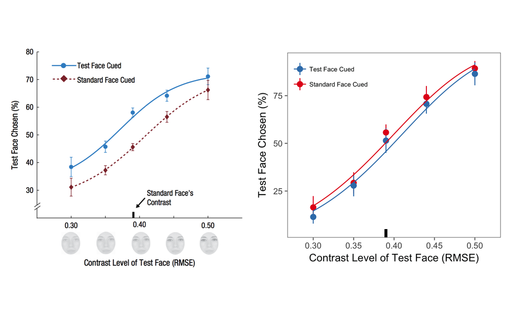

#### Key statistics: *Paired-samples t*

```r
# matched-face trials
d_sum <- tbl %>%
  group_by(workerid) %>%
  mutate(workerMean_3 = mean(pctTest)) %>%
  ungroup() %>%
  mutate(grandMean_3 = mean(workerMean)) %>%
  mutate(newPct3 = pctTest - workerMean_3 + grandMean_3)
d_t <- d_sum[d_sum$testContrast=="3",]

bar <- d_t %>%
  group_by(cue) %>%
   # mean and within subject errors
  summarise(avePct=mean(pctTest), se=sd(newPct3)/sqrt(n()),
            ntrial=mean(n), aveTestChosen=mean(testChosen),
            sumTest=sum(testChosen), sumN=sum(n))

bargraph<-bar %>%
  ggplot(aes(x=cue,y=avePct,fill=cue)) +
  geom_bar(stat = "identity", position = "dodge",width = 0.6) +
  geom_linerange(aes(ymin=avePct-se, ymax=avePct+se)) +
  ggthemes::theme_few() +
  xlab("Face Cued") +
  ylab("Test Face Chosen (%)") +
  theme(legend.position="none") +
  scale_y_continuous(limits = c(30, NA),oob = rescale_none) +
  scale_fill_brewer(type="qual",palette=6)
# bargraph
```

##### Conduct a paired t test (test vs. standard face, Contrast Level 3)

```r
#conduct a paired t-test (test VS standard face, Contrast=3)
ttest<-t.test(pctTest ~ cue, d_t, paired=TRUE)
ttest
```

```
##
##  Paired t-test
##
## data:  pctTest by cue
## t = 0.5, df = 6, p-value = 0.7
## alternative hypothesis: true difference in means is not equal to 0
## 95 percent confidence interval:
##  -18  27
## sample estimates:
## mean of the differences
##                     4.3
```

```r
# cohen's effect size measure
dz<-cohensD(pctTest ~ cue, data=d_t, method="paired")
print(dz)
```

```
## [1] 0.18
```

51.43% vs. 55.71%, $t$(6) = 0.47, $p$ = 0.66, $\eta^2$ = 0.02.

The original paper reported 55.8% vs. 45.8%, $t$(15) = 2.51, $p$ = .02, $\eta^2$ = .30.

##### Side-by-side comparison with the original graph

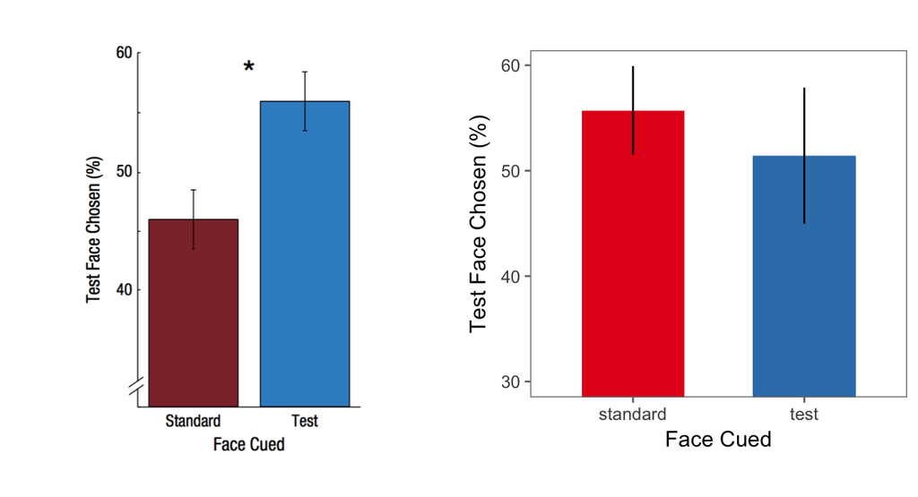

| Original | Replication |
| --- | --- |
| $t$(15) = 2.51, $p$ = .02, $\eta^2$ = .30 | $t$(6) = 0.47, $p$ = 0.66, $\eta^2$ = 0.02 |

### Exploratory analyses

#### Logistic regression

Fitting the logit to our binary response data using the GLM

```r
# data preparation
# adding a 0/1 binary response column in the raw dset
d$choice <- as.numeric(d$chosen) - 1
d$rms <-d$testContrast
levels(d$rms) <- RMScontrast
d$rms <- as.numeric(as.character(d$rms))
tbl$rms <-RMScontrast

# defining a function to perform logistic regression for individual data
logFit <- function(df,tb) {
logreg <- glm(formula = choice ~ cue + rms - 1, family = "binomial", df)
#get predicted responses from the model prediction
xseq <- seq(.3,.5,.001)
y_t <- predict(logreg,data.frame(cue="test",rms=xseq),type = "response")
y_s <- predict(logreg,data.frame(cue="standard",rms=xseq),type = "response")
#organize as data frame
curve_log <- data.frame(rbind(matrix(y_s),matrix(y_t)))
colnames(curve_log) = "yseq"
curve_log$cue <-rbind(matrix(rep("standard",npoints)), matrix(rep("test",npoints)))
curve_log$xseq = xseq

logplot <- df %>%ggplot(aes(x=rms,y=choice)) +
  geom_point(aes(x=rms, y=choice, color=cue),shape=21, fill=NA,alpha=0.7,
             position=position_jitter(width =.006,height = .04)) +
  geom_line(data=curve_log,aes(x=xseq,y=yseq,color=cue)) +
  ggthemes::theme_few() +
  theme(legend.position="none") +
  geom_point(data=tb,aes(x=rms, y=pctTest/100, color=cue)) +
  ylab("p test") +
  xlab("RMSE") +
  scale_color_brewer(type="qual",palette=6)
return(logplot)
}
```

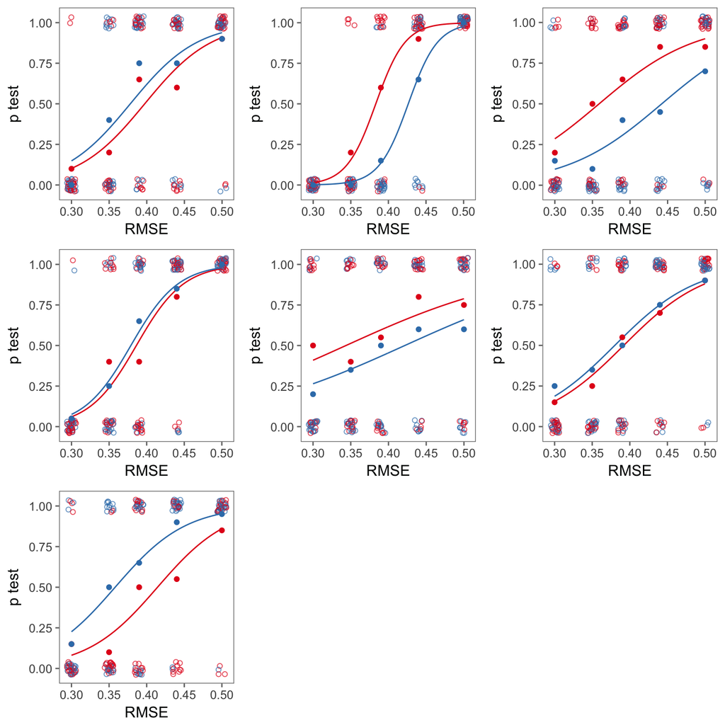

```r
# for loop to generate figures for each participant
workerID=unique(d$workerid)
plots <- list()
for (i in 1:numWorkers) {
  plots[[i]] <- logFit(d[d$workerid==workerID[i],], tbl[tbl$workerid==workerID[i],])
}
# plotting all
do.call(grid.arrange,c(plots,ncol=3))
```

##### Individual differences as a function of test contrast

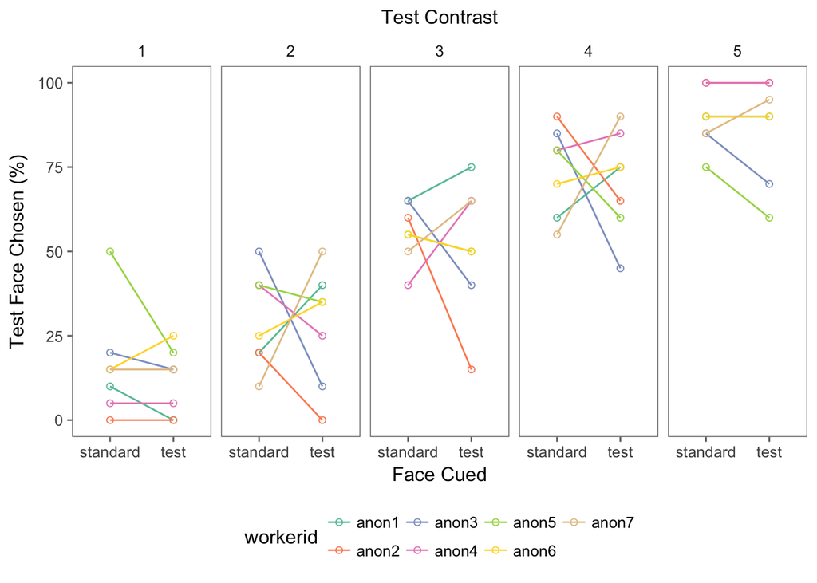

```r
# examine individual differences
d_sum %>% #only matched trials here
  ggplot(aes(x=cue,y=pctTest,group=workerid, color=workerid)) +
  geom_line() +
  geom_point(size=1.6, shape=21) +
  facet_grid(.~testContrast) +
  ggtitle("Test Contrast") +
  xlab("Face Cued") +
  ylab("Test Face Chosen (%)") +
  theme(plot.title = element_text(hjust = 0.5,size=rel(1)),
        legend.position = "bottom") +
  scale_color_brewer(type="qual",palette=7)
```

#### Mixed effects logistic regression

```r
# focusing on contrast level 3 only
# model comparisons?
d3 <- d[d$testContrast==3,]
# random intercept
log1 <- glmer(choice ~ cue + (1|workerid), family = "binomial", d3)
#random slope
log2 <- glmer(choice ~ cue + (1+cue|workerid), family = "binomial", d3)
anova(log1,log2)
```

```
## Data: d3
## Models:
## log1: choice ~ cue + (1 | workerid)
## log2: choice ~ cue + (1 + cue | workerid)
##      Df AIC BIC logLik deviance Chisq Chi Df Pr(>Chisq)
## log1  3 392 403   -193      386
## log2  5 390 409   -190      380  5.62      2       0.06 .
## ---
## Signif. codes:  0 '***' 0.001 '**' 0.01 '*' 0.05 '.' 0.1 ' ' 1
```

```r
# including all contrast levels.....
# model comparisons?
# random intercept
mixedLog1 <- glmer(choice ~ cue + rms + (1|workerid), family = "binomial", d)
mixedLog2 <- glmer(choice ~ cue * rms + (1|workerid), family = "binomial", d)
anova(mixedLog1,mixedLog2)
```

```
## Data: d
## Models:
## mixedLog1: choice ~ cue + rms + (1 | workerid)
## mixedLog2: choice ~ cue * rms + (1 | workerid)
##           Df  AIC  BIC logLik deviance Chisq Chi Df Pr(>Chisq)
## mixedLog1  4 1493 1514   -743     1485
## mixedLog2  5 1495 1521   -743     1485     0      1       0.96
```

```r
# random slope
mixedLog3 <- glmer(choice ~ cue + rms + (1+cue|workerid), family = "binomial", d)
anova(mixedLog1,mixedLog3)
```

```
## Data: d
## Models:
## mixedLog1: choice ~ cue + rms + (1 | workerid)
## mixedLog3: choice ~ cue + rms + (1 + cue | workerid)
##           Df  AIC  BIC logLik deviance Chisq Chi Df Pr(>Chisq)
## mixedLog1  4 1493 1514   -743     1485
## mixedLog3  6 1469 1500   -728     1457  28.5      2    6.6e-07 ***
## ---
## Signif. codes:  0 '***' 0.001 '**' 0.01 '*' 0.05 '.' 0.1 ' ' 1
```

```r
mixedLog4 <- glmer(choice ~ cue + rms + (1+cue+rms|workerid), family = "binomial", d)
anova(mixedLog4,mixedLog3)
```

```
## Data: d
## Models:
## mixedLog3: choice ~ cue + rms + (1 + cue | workerid)
## mixedLog4: choice ~ cue + rms + (1 + cue + rms | workerid)
##           Df  AIC  BIC logLik deviance Chisq Chi Df Pr(>Chisq)
## mixedLog3  6 1469 1500   -728     1457
## mixedLog4  9 1429 1477   -706     1411  45.5      3    7.4e-10 ***
## ---
## Signif. codes:  0 '***' 0.001 '**' 0.01 '*' 0.05 '.' 0.1 ' ' 1
```

```r
# item effect
# mixedLog5 <- glmer(choice ~ cue + rms + (1+cue+rms|workerid) + (1|whichSet), family = "binomial", d)
## model doesn't converge...
# anova(mixedLog5,mixedLog4)

summary(mixedLog4)
```

```
## Generalized linear mixed model fit by maximum likelihood (Laplace
##   Approximation) [glmerMod]
##  Family: binomial  ( logit )
## Formula: choice ~ cue + rms + (1 + cue + rms | workerid)
##    Data: d
##
##      AIC      BIC   logLik deviance df.resid
##     1429     1476     -706     1411     1391
##
## Scaled residuals:
##    Min     1Q Median     3Q    Max
## -4.384 -0.609  0.076  0.634  3.967
##
## Random effects:
##  Groups   Name        Variance Std.Dev. Corr
##  workerid (Intercept)  18.135   4.26
##           cuetest       0.902   0.95     0.26
##           rms         118.098  10.87    -1.00 -0.32
## Number of obs: 1400, groups:  workerid, 7
##
## Fixed effects:
##             Estimate Std. Error z value Pr(>|z|)
## (Intercept)   -8.937      1.699   -5.26  1.4e-07 ***
## cuetest       -0.259      0.386   -0.67      0.5
## rms           23.122      4.334    5.33  9.6e-08 ***
## ---
## Signif. codes:  0 '***' 0.001 '**' 0.01 '*' 0.05 '.' 0.1 ' ' 1
##
## Correlation of Fixed Effects:
##         (Intr) cuetst
## cuetest  0.226
## rms     -0.996 -0.299
## convergence code: 0
## Model failed to converge with max|grad| = 0.00808479 (tol = 0.001, component 1)
```

```r
sjp.setTheme(axis.textsize.x = 0.7)
sjp.glmer(mixedLog4, y.offset = .4)
```

```
## Plotting random effects...
```

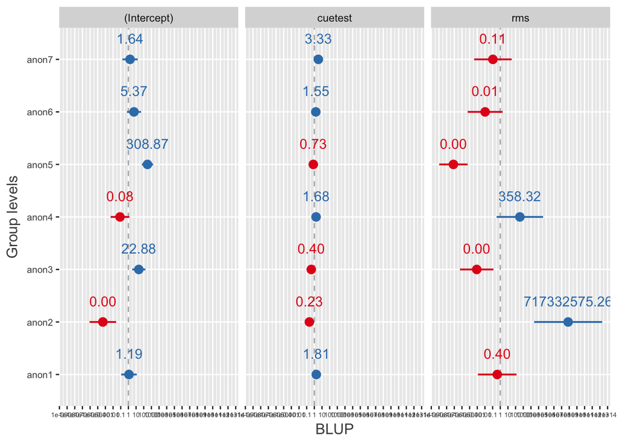

## Discussion

### Summary of Replication Attempt